# Introduction to Pandas for absolute beginners

The pandas package is the backbone of most data projects. The word pandas is an acronym which is derived from "Python and data analysis" and "panel data"

## Pandas First Steps: install & import

```python
%pip install pandas
```

```python
import pandas as pd
```

### Core components of pandas: Series and DataFrames

The primary two components of pandas are the Series and DataFrame.

A Series is essentially a column, and a DataFrame is a multi-dimensional table made up of a collection of Series.

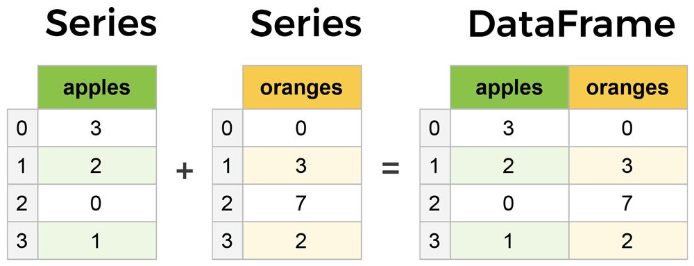

### Creating DataFrames from scratch using "dictionaries"

Let's say we have a fruit stand that sells apples and oranges.

We want to have a **column for each fruit** and a **row for each customer purchase**.

To organize this as a dictionary for pandas we could do something like:

```python
data = {
    'apples': [3,2,0,1],
    'oranges': [0,3,7,2]
}
print(data)
```

```
{'apples': [3, 2, 0, 1], 'oranges': [0, 3, 7, 2]}
```

And then pass it to the pandas DataFrame constructor:

```python
purchases= pd.DataFrame(data)
purchases
```

|  | apples | oranges |
| --- | --- | --- |
| 0 | 3 | 0 |
| 1 | 2 | 3 |
| 2 | 0 | 7 |
| 3 | 1 | 2 |

Each (key, value) item in data corresponds to a column in the resulting DataFrame.

The Index of this DataFrame was given to us on creation as the numbers 0-3, but we could also create our own when we initialize the DataFrame.

Let's have customer names as our index:

```python
purchases = pd.DataFrame(data,index = ['June', 'Robert', 'Lily', 'David'])
purchases
```

|  | apples | oranges |
| --- | --- | --- |
| June | 3 | 0 |
| Robert | 2 | 3 |
| Lily | 0 | 7 |
| David | 1 | 2 |

### Creating DataFrames from csv

(Note you can read from JSON & SQL as well)

```python
movies_df = pd.read_csv("IMDB-Movie-Data.csv")
movies_df.head(10)
```

|  | Rank | Title | Genre | Description | Director | Actors | Year | Runtime (Minutes) | Rating | Votes | Revenue (Millions) | Metascore |
| --- | --- | --- | --- | --- | --- | --- | --- | --- | --- | --- | --- | --- |
| 0 | 1 | Guardians of the Galaxy | Action,Adventure,Sci-Fi | A group of intergalactic criminals are forced ... | James Gunn | Chris Pratt, Vin Diesel, Bradley Cooper, Zoe S... | 2014 | 121 | 8.1 | 757074 | 333.13 | 76.0 |
| 1 | 2 | Prometheus | Adventure,Mystery,Sci-Fi | Following clues to the origin of mankind, a te... | Ridley Scott | Noomi Rapace, Logan Marshall-Green, Michael Fa... | 2012 | 124 | 7.0 | 485820 | 126.46 | 65.0 |
| 2 | 3 | Split | Horror,Thriller | Three girls are kidnapped by a man with a diag... | M. Night Shyamalan | James McAvoy, Anya Taylor-Joy, Haley Lu Richar... | 2016 | 117 | 7.3 | 157606 | 138.12 | 62.0 |
| 3 | 4 | Sing | Animation,Comedy,Family | In a city of humanoid animals, a hustling thea... | Christophe Lourdelet | Matthew McConaughey,Reese Witherspoon, Seth Ma... | 2016 | 108 | 7.2 | 60545 | 270.32 | 59.0 |
| 4 | 5 | Suicide Squad | Action,Adventure,Fantasy | A secret government agency recruits some of th... | David Ayer | Will Smith, Jared Leto, Margot Robbie, Viola D... | 2016 | 123 | 6.2 | 393727 | 325.02 | 40.0 |
| 5 | 6 | The Great Wall | Action,Adventure,Fantasy | European mercenaries searching for black powde... | Yimou Zhang | Matt Damon, Tian Jing, Willem Dafoe, Andy Lau | 2016 | 103 | 6.1 | 56036 | 45.13 | 42.0 |
| 6 | 7 | La La Land | Comedy,Drama,Music | A jazz pianist falls for an aspiring actress i... | Damien Chazelle | Ryan Gosling, Emma Stone, Rosemarie DeWitt, J.... | 2016 | 128 | 8.3 | 258682 | 151.06 | 93.0 |
| 7 | 8 | Mindhorn | Comedy | A has-been actor best known for playing the ti... | Sean Foley | Essie Davis, Andrea Riseborough, Julian Barrat... | 2016 | 89 | 6.4 | 2490 | NaN | 71.0 |
| 8 | 9 | The Lost City of Z | Action,Adventure,Biography | A true-life drama, centering on British explor... | James Gray | Charlie Hunnam, Robert Pattinson, Sienna Mille... | 2016 | 141 | 7.1 | 7188 | 8.01 | 78.0 |
| 9 | 10 | Passengers | Adventure,Drama,Romance | A spacecraft traveling to a distant colony pla... | Morten Tyldum | Jennifer Lawrence, Chris Pratt, Michael Sheen,... | 2016 | 116 | 7.0 | 192177 | 100.01 | 41.0 |

## Getting info about your data

.info() should be one of the very first commands you run after loading your data. .info() provides the essential details about your dataset, such as the number of rows and columns, the number of non-null values, what type of data is in each column, and how much memory your DataFrame is using.

Notice in our movies dataset we have some obvious missing values in the Revenue and Metascore columns. We'll look at how to handle those in a bit.

```python
movies_df.info()
```

```
<class 'pandas.core.frame.DataFrame'>
RangeIndex: 1000 entries, 0 to 999
Data columns (total 12 columns):
 #   Column              Non-Null Count  Dtype
---  ------              --------------  -----
 0   Rank                1000 non-null   int64
 1   Title               1000 non-null   object
 2   Genre               1000 non-null   object
 3   Description         1000 non-null   object
 4   Director            1000 non-null   object
 5   Actors              1000 non-null   object
 6   Year                1000 non-null   int64
 7   Runtime (Minutes)   1000 non-null   int64
 8   Rating              1000 non-null   float64
 9   Votes               1000 non-null   int64
 10  Revenue (Millions)  872 non-null    float64
 11  Metascore           936 non-null    float64
dtypes: float64(3), int64(4), object(5)
memory usage: 93.9+ KB
```

```python
movies_df.shape
```

```
(1000, 12)
```

### printing out & editing column names:

```python
print(movies_df.columns)
movies_df.columns = [col.lower() for col in movies_df]
print(movies_df.columns)
```

```
Index(['Rank', 'Title', 'Genre', 'Description', 'Director', 'Actors', 'Year',
       'Runtime (Minutes)', 'Rating', 'Votes', 'Revenue (Millions)',
       'Metascore'],
      dtype='object')
Index(['rank', 'title', 'genre', 'description', 'director', 'actors', 'year',
       'runtime (minutes)', 'rating', 'votes', 'revenue (millions)',
       'metascore'],
      dtype='object')
```

### Renaming certain or all columns:

```python
movies_df.rename(columns={
        'runtime (minutes)': 'runtime',
        'rating_category': 'rating',
        'revenue (millions)' : 'revenue'
    }, inplace=True)


movies_df.columns
```

```
Index(['rank', 'title', 'genre', 'description', 'director', 'actors', 'year',
       'runtime', 'rating', 'votes', 'revenue', 'metascore'],
      dtype='object')
```

### Understanding your variables

a summary of the distribution of `continuous` variables:

```python
movies_df.describe()
```

|  | rank | year | runtime | rating | votes | revenue | metascore |
| --- | --- | --- | --- | --- | --- | --- | --- |
| count | 1000.000000 | 1000.000000 | 1000.000000 | 1000.000000 | 1.000000e+03 | 872.000000 | 936.000000 |
| mean | 500.500000 | 2012.783000 | 113.172000 | 6.723200 | 1.698083e+05 | 82.956376 | 58.985043 |
| std | 288.819436 | 3.205962 | 18.810908 | 0.945429 | 1.887626e+05 | 103.253540 | 17.194757 |
| min | 1.000000 | 2006.000000 | 66.000000 | 1.900000 | 6.100000e+01 | 0.000000 | 11.000000 |
| 25% | 250.750000 | 2010.000000 | 100.000000 | 6.200000 | 3.630900e+04 | 13.270000 | 47.000000 |
| 50% | 500.500000 | 2014.000000 | 111.000000 | 6.800000 | 1.107990e+05 | 47.985000 | 59.500000 |
| 75% | 750.250000 | 2016.000000 | 123.000000 | 7.400000 | 2.399098e+05 | 113.715000 | 72.000000 |
| max | 1000.000000 | 2016.000000 | 191.000000 | 9.000000 | 1.791916e+06 | 936.630000 | 100.000000 |

a summary of a `categorical` variable: .describe() can also be used on a categorical variable to get the count of rows, unique count of categories, top category, and freq of top category

```python
movies_df['genre'].describe()
#This tells us that the genre column has 207 unique values,
#the top value is Action/Adventure/Sci-Fi,
#which shows up 50 times (freq)
```

```
count                        1000
unique                        207
top       Action,Adventure,Sci-Fi
freq                           50
Name: genre, dtype: object
```

the frequency of all values in a column:

```python
movies_df['genre'].value_counts()
```

```
genre
Action,Adventure,Sci-Fi    50
Drama                      48
Comedy,Drama,Romance       35
Comedy                     32
Drama,Romance              31
                           ..
Action,Comedy,Family        1
Action,Crime,Fantasy        1
Comedy,Mystery              1
Adventure,Comedy,Horror     1
Comedy,Family,Fantasy       1
Name: count, Length: 207, dtype: int64
```

Relationships between continuous variables:

```python
movies_df.corr(numeric_only=True)
```

|  | rank | year | runtime | rating | votes | revenue | metascore |
| --- | --- | --- | --- | --- | --- | --- | --- |
| rank | 1.000000 | -0.261605 | -0.221739 | -0.219555 | -0.283876 | -0.271592 | -0.191869 |
| year | -0.261605 | 1.000000 | -0.164900 | -0.211219 | -0.411904 | -0.126790 | -0.079305 |
| runtime | -0.221739 | -0.164900 | 1.000000 | 0.392214 | 0.407062 | 0.267953 | 0.211978 |
| rating | -0.219555 | -0.211219 | 0.392214 | 1.000000 | 0.511537 | 0.217654 | 0.631897 |
| votes | -0.283876 | -0.411904 | 0.407062 | 0.511537 | 1.000000 | 0.639661 | 0.325684 |
| revenue | -0.271592 | -0.126790 | 0.267953 | 0.217654 | 0.639661 | 1.000000 | 0.142397 |
| metascore | -0.191869 | -0.079305 | 0.211978 | 0.631897 | 0.325684 | 0.142397 | 1.000000 |

Correlation tables are a numerical representation of the bivariate relationships in the dataset.

Positive numbers indicate a positive correlation — one goes up the other goes up — and negative numbers represent an inverse correlation — one goes up the other goes down. 1.0 indicates a perfect correlation.

So looking in the first row, first column we see rank has a perfect correlation with itself, which is obvious. On the other hand, the correlation between votes and revenue_millions is 0.6. A little more interesting.

Examining bivariate relationships comes in handy when you have an outcome or dependent variable in mind and would like to see the features most correlated to the increase or decrease of the outcome.

## DataFrame slicing, selecting, extracting

##### Extracting by column:

```python
# By column:
genre_col = movies_df['genre']
print(genre_col)
# By a list of column names:
genre_col = movies_df[['genre','rating']]
print(genre_col)
```

```
0       Action,Adventure,Sci-Fi
1      Adventure,Mystery,Sci-Fi
2               Horror,Thriller
3       Animation,Comedy,Family
4      Action,Adventure,Fantasy
                 ...
995         Crime,Drama,Mystery
996                      Horror
997         Drama,Music,Romance
998            Adventure,Comedy
999       Comedy,Family,Fantasy
Name: genre, Length: 1000, dtype: object
                        genre  rating
0     Action,Adventure,Sci-Fi     8.1
1    Adventure,Mystery,Sci-Fi     7.0
2             Horror,Thriller     7.3
3     Animation,Comedy,Family     7.2
4    Action,Adventure,Fantasy     6.2
..                        ...     ...
995       Crime,Drama,Mystery     6.2
996                    Horror     5.5
997       Drama,Music,Romance     6.2
998          Adventure,Comedy     5.6
999     Comedy,Family,Fantasy     5.3

[1000 rows x 2 columns]
```

##### Extracting by rows:

For rows, we have two options:

- loc - locates by name
- iloc- locates by numerical index

```python
movies_df.iloc[0]
# you  can use .loc to locate by name
```

[output not shown]

##### Slicing:

```python
movies_df.iloc[0:3]
```

|  | rank | title | genre | description | director | actors | year | runtime | rating | votes | revenue | metascore |
| --- | --- | --- | --- | --- | --- | --- | --- | --- | --- | --- | --- | --- |
| 0 | 1 | Guardians of the Galaxy | Action,Adventure,Sci-Fi | A group of intergalactic criminals are forced ... | James Gunn | Chris Pratt, Vin Diesel, Bradley Cooper, Zoe S... | 2014 | 121 | 8.1 | 757074 | 333.13 | 76.0 |
| 1 | 2 | Prometheus | Adventure,Mystery,Sci-Fi | Following clues to the origin of mankind, a te... | Ridley Scott | Noomi Rapace, Logan Marshall-Green, Michael Fa... | 2012 | 124 | 7.0 | 485820 | 126.46 | 65.0 |
| 2 | 3 | Split | Horror,Thriller | Three girls are kidnapped by a man with a diag... | M. Night Shyamalan | James McAvoy, Anya Taylor-Joy, Haley Lu Richar... | 2016 | 117 | 7.3 | 157606 | 138.12 | 62.0 |

##### Conditional selections:

filter our movies DataFrame to show only films directed by Ridley Scott?

```python
movies_df['director']=='Ridley Scott'
```

```
0      False
1       True
2      False
3      False
4      False
       ...
995    False
996    False
997    False
998    False
999    False
Name: director, Length: 1000, dtype: bool
```

```python
movies_df[movies_df['director']=='Ridley Scott']
```

|  | rank | title | genre | description | director | actors | year | runtime | rating | votes | revenue | metascore |
| --- | --- | --- | --- | --- | --- | --- | --- | --- | --- | --- | --- | --- |
| 1 | 2 | Prometheus | Adventure,Mystery,Sci-Fi | Following clues to the origin of mankind, a te... | Ridley Scott | Noomi Rapace, Logan Marshall-Green, Michael Fa... | 2012 | 124 | 7.0 | 485820 | 126.46 | 65.0 |
| 102 | 103 | The Martian | Adventure,Drama,Sci-Fi | An astronaut becomes stranded on Mars after hi... | Ridley Scott | Matt Damon, Jessica Chastain, Kristen Wiig, Ka... | 2015 | 144 | 8.0 | 556097 | 228.43 | 80.0 |
| 387 | 388 | Robin Hood | Action,Adventure,Drama | In 12th century England, Robin and his band of... | Ridley Scott | Russell Crowe, Cate Blanchett, Matthew Macfady... | 2010 | 140 | 6.7 | 221117 | 105.22 | 53.0 |
| 470 | 471 | American Gangster | Biography,Crime,Drama | In 1970s America, a detective works to bring d... | Ridley Scott | Denzel Washington, Russell Crowe, Chiwetel Eji... | 2007 | 157 | 7.8 | 337835 | 130.13 | 76.0 |
| 516 | 517 | Exodus: Gods and Kings | Action,Adventure,Drama | The defiant leader Moses rises up against the ... | Ridley Scott | Christian Bale, Joel Edgerton, Ben Kingsley, S... | 2014 | 150 | 6.0 | 137299 | 65.01 | 52.0 |
| 521 | 522 | The Counselor | Crime,Drama,Thriller | A lawyer finds himself in over his head when h... | Ridley Scott | Michael Fassbender, Penélope Cruz, Cameron Dia... | 2013 | 117 | 5.3 | 84927 | 16.97 | 48.0 |
| 530 | 531 | A Good Year | Comedy,Drama,Romance | A British investment broker inherits his uncle... | Ridley Scott | Russell Crowe, Abbie Cornish, Albert Finney, M... | 2006 | 117 | 6.9 | 74674 | 7.46 | 47.0 |
| 737 | 738 | Body of Lies | Action,Drama,Romance | A CIA agent on the ground in Jordan hunts down... | Ridley Scott | Leonardo DiCaprio, Russell Crowe, Mark Strong,... | 2008 | 128 | 7.1 | 182305 | 39.38 | 57.0 |

```python
movies_df[movies_df['rating'] >=8.3].head(5)
```

|  | rank | title | genre | description | director | actors | year | runtime | rating | votes | revenue | metascore |
| --- | --- | --- | --- | --- | --- | --- | --- | --- | --- | --- | --- | --- |
| 6 | 7 | La La Land | Comedy,Drama,Music | A jazz pianist falls for an aspiring actress i... | Damien Chazelle | Ryan Gosling, Emma Stone, Rosemarie DeWitt, J.... | 2016 | 128 | 8.3 | 258682 | 151.06 | 93.0 |
| 26 | 27 | Bahubali: The Beginning | Action,Adventure,Drama | In ancient India, an adventurous and daring ma... | S.S. Rajamouli | Prabhas, Rana Daggubati, Anushka Shetty,Tamann... | 2015 | 159 | 8.3 | 76193 | 6.50 | NaN |
| 36 | 37 | Interstellar | Adventure,Drama,Sci-Fi | A team of explorers travel through a wormhole ... | Christopher Nolan | Matthew McConaughey, Anne Hathaway, Jessica Ch... | 2014 | 169 | 8.6 | 1047747 | 187.99 | 74.0 |
| 54 | 55 | The Dark Knight | Action,Crime,Drama | When the menace known as the Joker wreaks havo... | Christopher Nolan | Christian Bale, Heath Ledger, Aaron Eckhart,Mi... | 2008 | 152 | 9.0 | 1791916 | 533.32 | 82.0 |
| 64 | 65 | The Prestige | Drama,Mystery,Sci-Fi | Two stage magicians engage in competitive one-... | Christopher Nolan | Christian Bale, Hugh Jackman, Scarlett Johanss... | 2006 | 130 | 8.5 | 913152 | 53.08 | 66.0 |

filter the the DataFrame to show only movies by Christopher Nolan OR Ridley Scott?

```python
movies_df[movies_df['director'].isin(['Christopher Nolan', 'Ridley Scott'])].head(5)
# movies_df[(movies_df['director']=='Christopher Nolan') | (movies_df['director']=='Ridley Scott')]
```

|  | rank | title | genre | description | director | actors | year | runtime | rating | votes | revenue | metascore |
| --- | --- | --- | --- | --- | --- | --- | --- | --- | --- | --- | --- | --- |
| 1 | 2 | Prometheus | Adventure,Mystery,Sci-Fi | Following clues to the origin of mankind, a te... | Ridley Scott | Noomi Rapace, Logan Marshall-Green, Michael Fa... | 2012 | 124 | 7.0 | 485820 | 126.46 | 65.0 |
| 36 | 37 | Interstellar | Adventure,Drama,Sci-Fi | A team of explorers travel through a wormhole ... | Christopher Nolan | Matthew McConaughey, Anne Hathaway, Jessica Ch... | 2014 | 169 | 8.6 | 1047747 | 187.99 | 74.0 |
| 54 | 55 | The Dark Knight | Action,Crime,Drama | When the menace known as the Joker wreaks havo... | Christopher Nolan | Christian Bale, Heath Ledger, Aaron Eckhart,Mi... | 2008 | 152 | 9.0 | 1791916 | 533.32 | 82.0 |
| 64 | 65 | The Prestige | Drama,Mystery,Sci-Fi | Two stage magicians engage in competitive one-... | Christopher Nolan | Christian Bale, Hugh Jackman, Scarlett Johanss... | 2006 | 130 | 8.5 | 913152 | 53.08 | 66.0 |
| 80 | 81 | Inception | Action,Adventure,Sci-Fi | A thief, who steals corporate secrets through ... | Christopher Nolan | Leonardo DiCaprio, Joseph Gordon-Levitt, Ellen... | 2010 | 148 | 8.8 | 1583625 | 292.57 | 74.0 |

We can make some richer conditionals by using logical operators | for "or" and & for "and".

We need to make sure to group evaluations with parentheses so Python knows how to evaluate the conditional.

Let's say we want all movies that were released between 2005 and 2010, have a rating above 8.0, but made below the 25th percentile in revenue.

```python
movies_df[
    ((movies_df['year'] >= 2005) & (movies_df['year'] <= 2010))
    & (movies_df['rating'] > 8.0)
    & (movies_df['revenue'] < movies_df['revenue'].quantile(0.25))
]
```

[output not shown]

## Exploring data tools

#### Dropping duplicates

Pandas has the inplace keyword argument on many of its methods. Using inplace=True will modify the DataFrame object in place.

An important argument for drop_duplicates() is keep, which has three possible options:

- first: (default) Drop duplicates except for the first occurrence.
- last: Drop duplicates except for the last occurrence.
- False: Drop all duplicates.

```python
movies_df.drop_duplicates(keep="first", inplace=True)
```

#### working with missing values

When exploring data, you’ll most likely encounter missing or null values, which are essentially placeholders for non-existent values. Most commonly you'll see Python's None or NumPy's np.nan.

There are two options in dealing with nulls:

- Get rid of rows or columns with nulls
- Replace nulls with non-null values, a technique known as imputation

##### which cells in our DataFrame are null?

```python
movies_df.isnull().head(5)
```

|  | rank | title | genre | description | director | actors | year | runtime | rating | votes | revenue | metascore |
| --- | --- | --- | --- | --- | --- | --- | --- | --- | --- | --- | --- | --- |
| 0 | False | False | False | False | False | False | False | False | False | False | False | False |
| 1 | False | False | False | False | False | False | False | False | False | False | False | False |
| 2 | False | False | False | False | False | False | False | False | False | False | False | False |
| 3 | False | False | False | False | False | False | False | False | False | False | False | False |
| 4 | False | False | False | False | False | False | False | False | False | False | False | False |

##### count the number of nulls in each column ?

```python
movies_df.isnull().sum(axis=0)
```

```
rank             0
title            0
genre            0
description      0
director         0
actors           0
year             0
runtime          0
rating           0
votes            0
revenue        128
metascore       64
dtype: int64
```

##### Removing rows with null values:

```python
movies_df.dropna().shape
```

```
(838, 12)
```

##### Removing columns with null values:

```python
movies_df.dropna(axis=1).shape
```

```
(1000, 10)
```

##### Imputation

Imputation is a conventional feature engineering technique used to keep valuable data that have null values.

There may be instances where dropping every row with a null value removes too big a chunk from your dataset, so instead we can impute that null with another value, usually the **mean** or the **median** of that column.

```python
movies_df['revenue'].fillna(movies_df['revenue'].mean(),inplace=True)
movies_df.isnull().sum()
```

```
rank            0
title           0
genre           0
description     0
director        0
actors          0
year            0
runtime         0
rating          0
votes           0
revenue         0
metascore      64
dtype: int64
```

## Applying functions

It is possible to iterate over a DataFrame or Series as you would with a list, but doing so — especially on large datasets — is very slow.

An efficient alternative is to apply() a function to the dataset.

For example, we could use a function to convert movies with an 8.0 or greater to a string value of "good" and the rest to "bad" and use this transformed values to create a new column.

```python
movies_df["rating_category"] = movies_df["rating"].apply(lambda x: 'good' if x >= 8.0 else 'bad')

movies_df.head(10)
```

|  | rank | title | genre | description | director | actors | year | runtime | rating | votes | revenue | metascore | rating_category |
| --- | --- | --- | --- | --- | --- | --- | --- | --- | --- | --- | --- | --- | --- |
| 0 | 1 | Guardians of the Galaxy | Action,Adventure,Sci-Fi | A group of intergalactic criminals are forced ... | James Gunn | Chris Pratt, Vin Diesel, Bradley Cooper, Zoe S... | 2014 | 121 | 8.1 | 757074 | 333.130000 | 76.0 | good |
| 1 | 2 | Prometheus | Adventure,Mystery,Sci-Fi | Following clues to the origin of mankind, a te... | Ridley Scott | Noomi Rapace, Logan Marshall-Green, Michael Fa... | 2012 | 124 | 7.0 | 485820 | 126.460000 | 65.0 | bad |
| 2 | 3 | Split | Horror,Thriller | Three girls are kidnapped by a man with a diag... | M. Night Shyamalan | James McAvoy, Anya Taylor-Joy, Haley Lu Richar... | 2016 | 117 | 7.3 | 157606 | 138.120000 | 62.0 | bad |
| 3 | 4 | Sing | Animation,Comedy,Family | In a city of humanoid animals, a hustling thea... | Christophe Lourdelet | Matthew McConaughey,Reese Witherspoon, Seth Ma... | 2016 | 108 | 7.2 | 60545 | 270.320000 | 59.0 | bad |
| 4 | 5 | Suicide Squad | Action,Adventure,Fantasy | A secret government agency recruits some of th... | David Ayer | Will Smith, Jared Leto, Margot Robbie, Viola D... | 2016 | 123 | 6.2 | 393727 | 325.020000 | 40.0 | bad |
| 5 | 6 | The Great Wall | Action,Adventure,Fantasy | European mercenaries searching for black powde... | Yimou Zhang | Matt Damon, Tian Jing, Willem Dafoe, Andy Lau | 2016 | 103 | 6.1 | 56036 | 45.130000 | 42.0 | bad |
| 6 | 7 | La La Land | Comedy,Drama,Music | A jazz pianist falls for an aspiring actress i... | Damien Chazelle | Ryan Gosling, Emma Stone, Rosemarie DeWitt, J.... | 2016 | 128 | 8.3 | 258682 | 151.060000 | 93.0 | good |
| 7 | 8 | Mindhorn | Comedy | A has-been actor best known for playing the ti... | Sean Foley | Essie Davis, Andrea Riseborough, Julian Barrat... | 2016 | 89 | 6.4 | 2490 | 82.956376 | 71.0 | bad |
| 8 | 9 | The Lost City of Z | Action,Adventure,Biography | A true-life drama, centering on British explor... | James Gray | Charlie Hunnam, Robert Pattinson, Sienna Mille... | 2016 | 141 | 7.1 | 7188 | 8.010000 | 78.0 | bad |
| 9 | 10 | Passengers | Adventure,Drama,Romance | A spacecraft traveling to a distant colony pla... | Morten Tyldum | Jennifer Lawrence, Chris Pratt, Michael Sheen,... | 2016 | 116 | 7.0 | 192177 | 100.010000 | 41.0 | bad |

## Write back to csv

```python
movies_df.to_csv("new_file.csv")
```

### Honorable mentions of useful methods

```python
movies_df.dtypes
```

```
rank                 int64
title               object
genre               object
description         object
director            object
actors              object
year                 int64
runtime              int64
rating             float64
votes                int64
revenue            float64
metascore          float64
rating_category     object
dtype: object
```

```python
movies_df.sort_values(by="rating",ascending=False).head(3)
```

|  | rank | title | genre | description | director | actors | year | runtime | rating | votes | revenue | metascore | rating_category |
| --- | --- | --- | --- | --- | --- | --- | --- | --- | --- | --- | --- | --- | --- |
| 54 | 55 | The Dark Knight | Action,Crime,Drama | When the menace known as the Joker wreaks havo... | Christopher Nolan | Christian Bale, Heath Ledger, Aaron Eckhart,Mi... | 2008 | 152 | 9.0 | 1791916 | 533.32 | 82.0 | good |
| 80 | 81 | Inception | Action,Adventure,Sci-Fi | A thief, who steals corporate secrets through ... | Christopher Nolan | Leonardo DiCaprio, Joseph Gordon-Levitt, Ellen... | 2010 | 148 | 8.8 | 1583625 | 292.57 | 74.0 | good |
| 117 | 118 | Dangal | Action,Biography,Drama | Former wrestler Mahavir Singh Phogat and his t... | Nitesh Tiwari | Aamir Khan, Sakshi Tanwar, Fatima Sana Shaikh,... | 2016 | 161 | 8.8 | 48969 | 11.15 | NaN | good |

.concat(), .groupby() and many more useful methods

credit: https://www.learndatasci.com/tutorials/python-pandas-tutorial-complete-introduction-for-beginners/